# 2022 Rating Curves

Clean and plot our measured air pressure

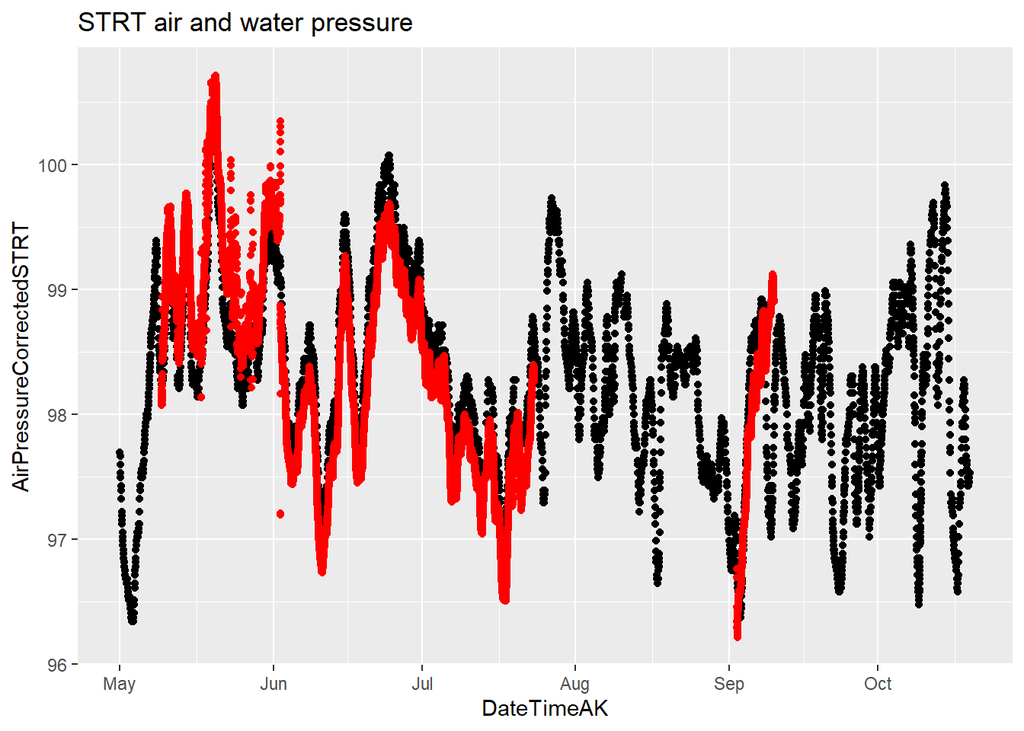

```r
# Plot STRT measured and Eilson air pressure
STRT.atmo.2022.compare <- full_join(eielson.atmo.2022.compare, strt.atmo.2022, by = "DateTimeAK")

STRT.atmo.2022.compare %>% filter(DateTimeAK > "2022-05-01") %>% ggplot() + geom_point(aes(DateTimeAK, AirPressureCorrectedSTRT)) +
  geom_point(aes(DateTimeAK, AirPressureSTRT), color = "red") +
  ggtitle("STRT air and water pressure")
```

Our air pressure is so messy: lets use Eielson air pressure

```r
# join the two atmospheric and water pressure together
STRT.2022 <- left_join(eielson.atmo.2022.compare, strt.final.pressure.2022, by = "DateTimeAK")

# Water pressure - atmospheric pressure
STRT.2022$difference <- STRT.2022$WaterPressure - STRT.2022$AirPressureCorrectedSTRT

STRT.2022 <-  STRT.2022 %>% filter(!difference %in% NA)
```

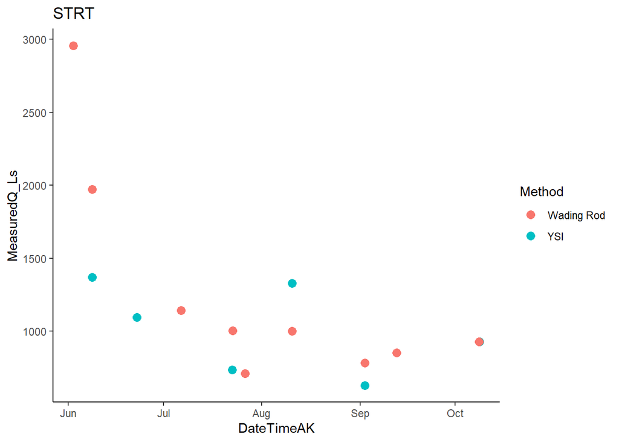

```r
### Filter STRT ###
QSummary.ST.2022 <- QSummary.2022 %>% filter(Site =="STRT")

ggplot(QSummary.ST.2022) +
  geom_point(aes(x = DateTimeAK, y = MeasuredQ_Ls, color = Method), size=3) +
  theme_classic() +
  ggtitle("STRT")
```

```r
# trying to merge by nearest date if we have an offset point
STRT.2022.dt <- setDT(STRT.2022)
QSummary.ST.2022.dt <- QSummary.ST.2022

Stuart1comb.2022 <- STRT.2022.dt[QSummary.ST.2022.dt, on = "DateTimeAK", roll = 'nearest']
```

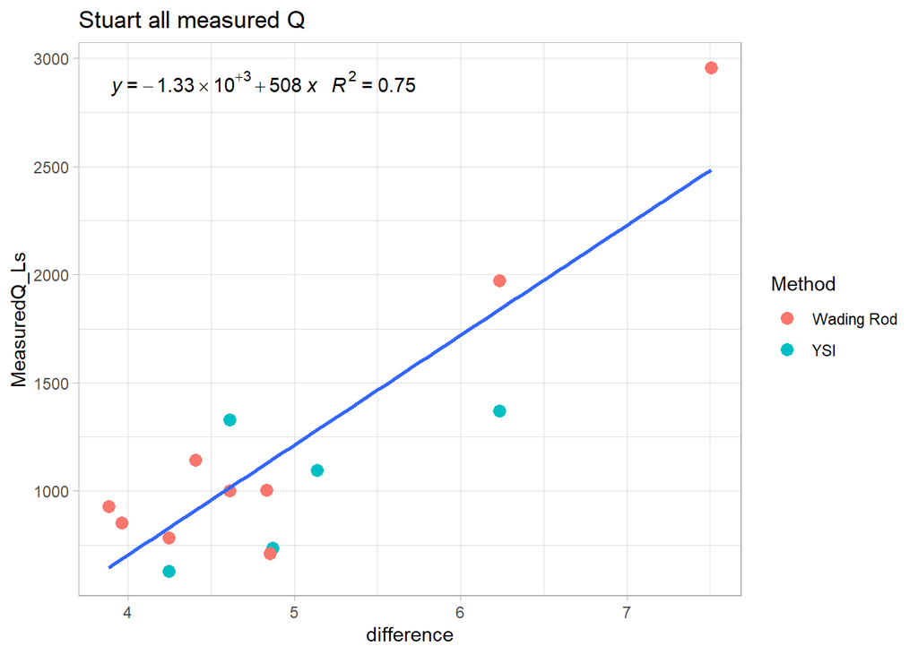

```r
### Filter STRT ###
strt.formula <- y ~ x

ggplot(aes(x = difference, y = MeasuredQ_Ls), data = Stuart1comb.2022) +
  geom_point(aes(color = Method), size = 3) +
  geom_smooth(method = "lm", se=FALSE, formula = strt.formula) +
  stat_poly_eq(formula = strt.formula,
               aes(label = paste(..eq.label.., ..rr.label.., sep = "~~~")),
               parse = TRUE) +
  theme_light() +
  ggtitle("Stuart all measured Q")
```

Not so bad. Stuart looks like a quadratic relationship might fit better.

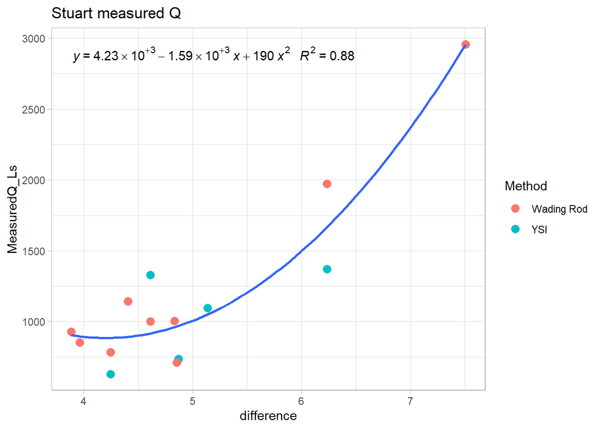

```r
strt.formula <- y ~ poly(x, 2, raw = TRUE)

ggplot(aes(x = difference, y = MeasuredQ_Ls), data = Stuart1comb.2022) +
  geom_point(aes(color = Method), size = 3) +
  geom_smooth(method = "lm", se=FALSE, formula = strt.formula) +
  stat_poly_eq(formula = strt.formula,
               aes(label = paste(..eq.label.., ..rr.label.., sep = "~~~")),
               parse = TRUE) +
  theme_light() +
  ggtitle("Stuart measured Q")
```

The relationship is not strong at low Q. Lets remove the two points with difference > 4.8 and MeasuredQ_Ls < 800.

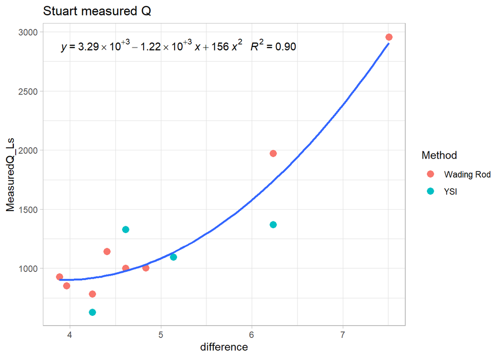

```r
strt.formula <- y ~ poly(x, 2, raw = TRUE)
Stuart1comb.2022.2 <- Stuart1comb.2022 %>% filter(difference < 4.8 | MeasuredQ_Ls > 800)
ggplot(aes(x = difference, y = MeasuredQ_Ls), data = Stuart1comb.2022.2) +
  geom_point(aes(color = Method), size = 3) +
  geom_smooth(method = "lm", se=FALSE, formula = strt.formula) +
  stat_poly_eq(formula = strt.formula,
               aes(label = paste(..eq.label.., ..rr.label.., sep = "~~~")),
               parse = TRUE) +
  theme_light() +
  ggtitle("Stuart measured Q")
```

```r
## Predict STRT Q
STRT1.lm.2022 <- lm(Stuart1comb.2022.2$MeasuredQ_Ls ~ Stuart1comb.2022.2$difference + I(Stuart1comb.2022.2$difference^2))
summary(STRT1.lm.2022)
```

```
##
## Call:
## lm(formula = Stuart1comb.2022.2$MeasuredQ_Ls ~ Stuart1comb.2022.2$difference +
##     I(Stuart1comb.2022.2$difference^2))
##
## Residuals:
##     Min      1Q  Median      3Q     Max
## -370.00  -50.39   24.38   50.11  351.77
##
## Coefficients:
##                                    Estimate Std. Error t value Pr(>|t|)
## (Intercept)                         3285.33    1626.51   2.020   0.0710 .
## Stuart1comb.2022.2$difference      -1217.56     611.25  -1.992   0.0744 .
## I(Stuart1comb.2022.2$difference^2)   155.52      54.95   2.830   0.0178 *
## ---
## Signif. codes:  0 '***' 0.001 '**' 0.01 '*' 0.05 '.' 0.1 ' ' 1
##
## Residual standard error: 215.8 on 10 degrees of freedom
##   (1 observation deleted due to missingness)
## Multiple R-squared:  0.8982, Adjusted R-squared:  0.8778
## F-statistic:  44.1 on 2 and 10 DF,  p-value: 1.095e-05
```

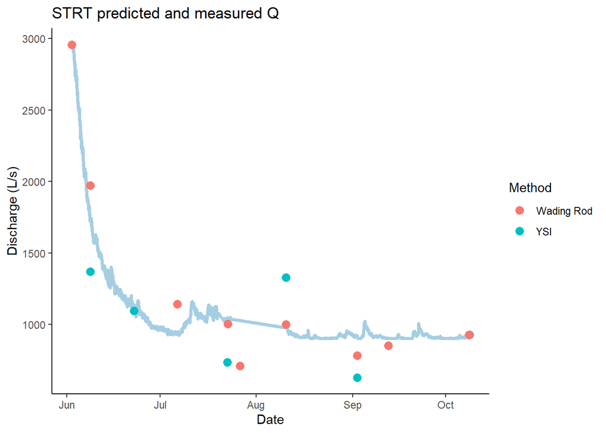

```r
STRT.2022.dt$pred.strt1.Q <- coef(STRT1.lm.2022)[2] * STRT.2022.dt$difference + coef(STRT1.lm.2022)[3] * I(STRT.2022.dt$difference^2) + coef(STRT1.lm.2022)[1]

STRT.2022.dt %>% na.omit() %>% ggplot(aes(x = DateTimeAK, y = pred.strt1.Q)) +
  geom_line(color="#A6CEE3", size=1.25) +
  geom_point(data = Stuart1comb.2022, aes(x = DateTimeAK, y = MeasuredQ_Ls, color = Method), size=3) +
  theme_classic() +
  ggtitle("STRT predicted and measured Q") +
  xlab("Date") +
  ylab("Discharge (L/s)")
```

I’ll try a curve with just wading rod points.

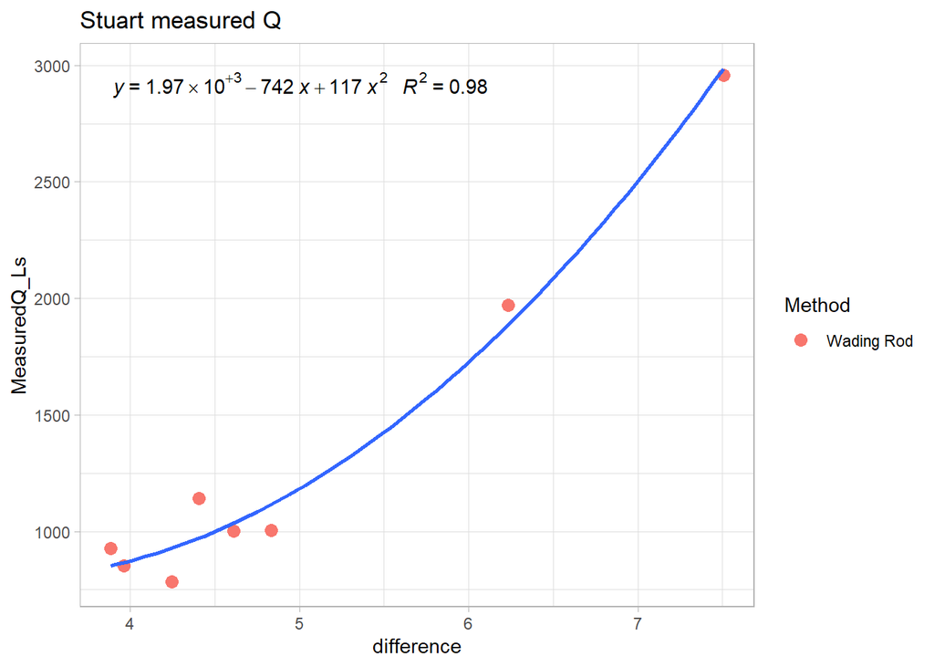

```r
strt.formula <- y ~ poly(x, 2, raw = TRUE)
Stuart1comb.2022.3 <- Stuart1comb.2022 %>% filter(difference < 4.8 | MeasuredQ_Ls > 800, Method == "Wading Rod")
ggplot(aes(x = difference, y = MeasuredQ_Ls), data = Stuart1comb.2022.3) +
  geom_point(aes(color = Method), size = 3) +
  geom_smooth(method = "lm", se=FALSE, formula = strt.formula) +
  stat_poly_eq(formula = strt.formula,
               aes(label = paste(..eq.label.., ..rr.label.., sep = "~~~")),
               parse = TRUE) +
  theme_light() +
  ggtitle("Stuart measured Q")
```

Have we cheated? Let me check how low the R2 is when difference < 5.

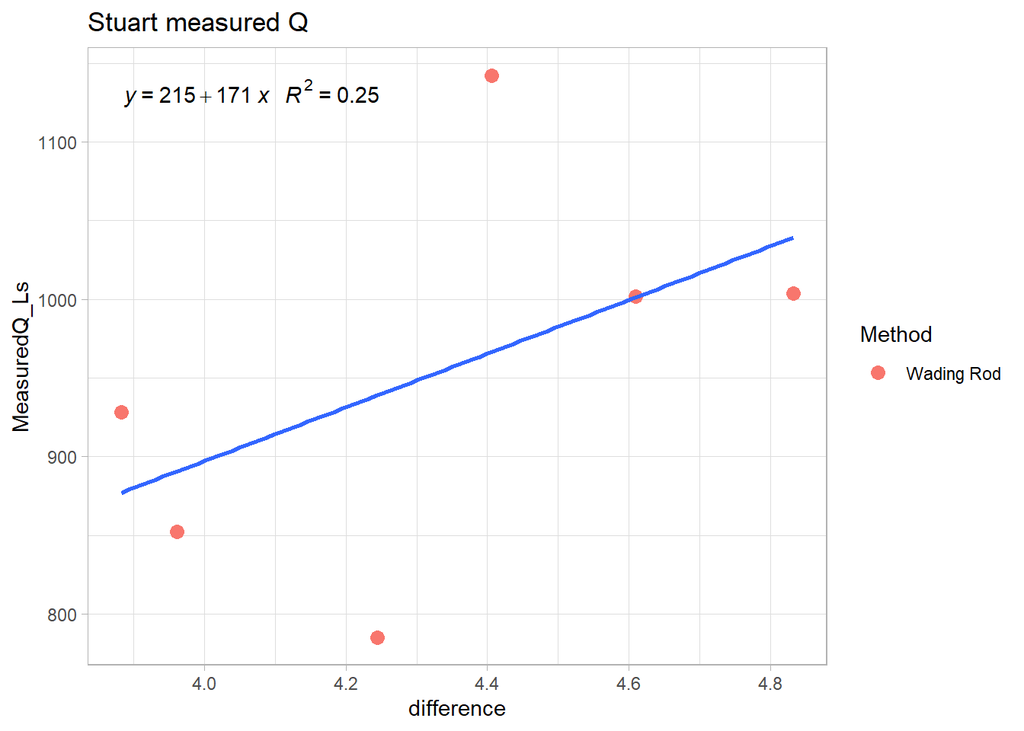

```r
strt.formula <- y ~ x
Stuart1comb.2022.4 <- Stuart1comb.2022 %>% filter(difference < 4.8 | MeasuredQ_Ls > 800, difference < 5, Method == "Wading Rod")
ggplot(aes(x = difference, y = MeasuredQ_Ls), data = Stuart1comb.2022.4) +
  geom_point(aes(color = Method), size = 3) +
  geom_smooth(method = "lm", se=FALSE, formula = strt.formula) +
  stat_poly_eq(formula = strt.formula,
               aes(label = paste(..eq.label.., ..rr.label.., sep = "~~~")),
               parse = TRUE) +
  theme_light() +
  ggtitle("Stuart measured Q")
```

Here is the predicted Q using the Q curve with all but one wading rod point.

```r
## Predict STRT Q
STRT1.lm.2022.2 <- lm(Stuart1comb.2022.3$MeasuredQ_Ls ~ Stuart1comb.2022.3$difference + I(Stuart1comb.2022.3$difference^2))
summary(STRT1.lm.2022.2)
```

```
##
## Call:
## lm(formula = Stuart1comb.2022.3$MeasuredQ_Ls ~ Stuart1comb.2022.3$difference +
##     I(Stuart1comb.2022.3$difference^2))
##
## Residuals:
##       1       2       3       4       5       6       7       8
##  -28.05   82.71  170.88 -111.37  -32.86 -142.70  -14.19   75.57
##
## Coefficients:
##                                    Estimate Std. Error t value Pr(>|t|)
## (Intercept)                         1972.10    1225.10   1.610   0.1684
## Stuart1comb.2022.3$difference       -742.03     456.03  -1.627   0.1646
## I(Stuart1comb.2022.3$difference^2)   116.86      40.14   2.911   0.0334 *
## ---
## Signif. codes:  0 '***' 0.001 '**' 0.01 '*' 0.05 '.' 0.1 ' ' 1
##
## Residual standard error: 123.8 on 5 degrees of freedom
## Multiple R-squared:  0.9808, Adjusted R-squared:  0.9732
## F-statistic: 127.9 on 2 and 5 DF,  p-value: 5.088e-05
```

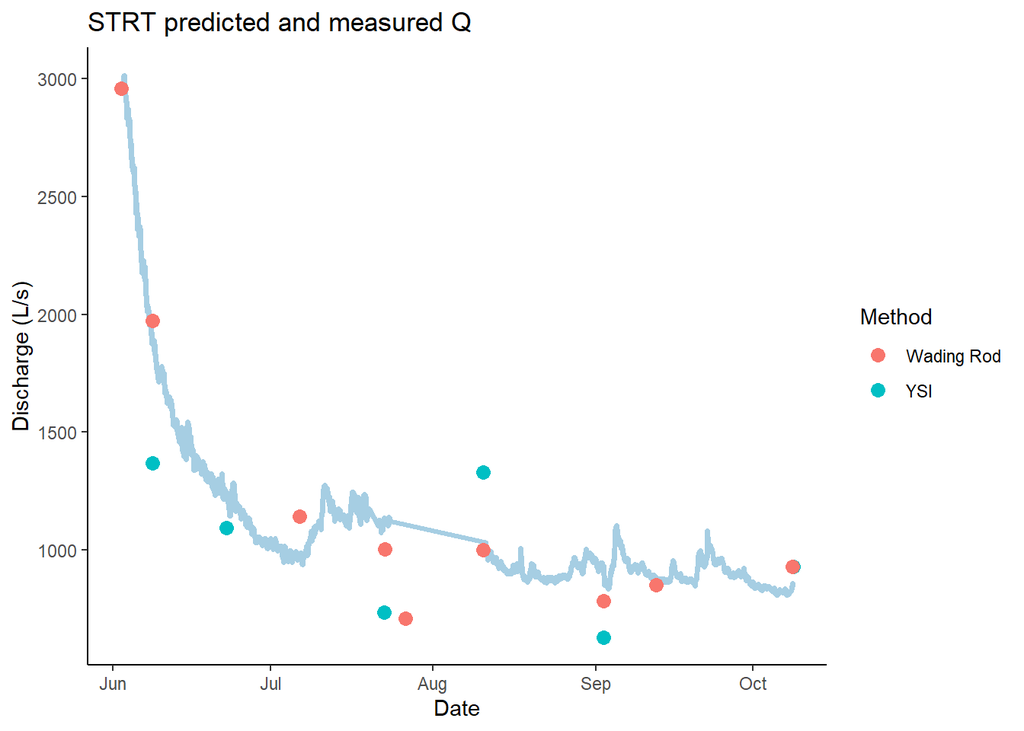

```r
STRT.2022.dt$pred.strt1.Q.2 <- coef(STRT1.lm.2022.2)[2] * STRT.2022.dt$difference + coef(STRT1.lm.2022.2)[3] * I(STRT.2022.dt$difference^2) + coef(STRT1.lm.2022.2)[1]

STRT.2022.dt %>% na.omit() %>% ggplot(aes(x = DateTimeAK, y = pred.strt1.Q.2)) +
  geom_line(color="#A6CEE3", size=1.25) +
  geom_point(data = Stuart1comb.2022, aes(x = DateTimeAK, y = MeasuredQ_Ls, color = Method), size=3) +
  theme_classic() +
  ggtitle("STRT predicted and measured Q") +
  xlab("Date") +
  ylab("Discharge (L/s)")
```

Is this better than the first one?

### FRCH

```r
frch.stream.one.2022.url <- "https://docs.google.com/spreadsheets/d/e/2PACX-1vRkT5GIhFY4nLblzPi4Upc8y6Pk2k4vXLSGAkFyMhLowsCmct0fZ5rxm-vd85RfFr7YLrCuuSiOqQbL/pub?output=csv"
frch.stream.two.2022.url <-  "https://docs.google.com/spreadsheets/d/e/2PACX-1vRiDAbzBj_jHk1Hd3iM7fFvzMrRCSF9fbKTcmQD_dUFGOjoIQuBZBKV4KdNhfevLOq0Udch0LbWiKXw/pub?output=csv"

# load in url
frch.stream.one.2022 <- read.csv(url(frch.stream.one.2022.url), skip = 1)
frch.stream.two.2022 <- read.csv(url(frch.stream.two.2022.url), skip = 1)

# clean for merging purposes
frch.stream.one.2022 <- frch.stream.one.2022[, -c(5:13)] # removing columns that arent date/abs pressure and temp

frch.stream.two.2022 <- frch.stream.two.2022[, -c(5:14)] # removing columns that arent date/abs pressure and temp

# changing to AK time (It reads in as GMT but it is actually AKST )
frch.stream.one.2022$DateTimeAK <- mdy_hms(frch.stream.one.2022$Date.Time..GMT.08.00)

frch.stream.two.2022$DateTimeAK <- mdy_hms(frch.stream.two.2022$Date.Time..GMT.08.00)

frch.stream.two.2022$DateTimeAK <- force_tz(frch.stream.two.2022$DateTimeAK, tzone = "America/Anchorage")

frch.stream.one.2022$DateTimeAK <- force_tz(frch.stream.one.2022$DateTimeAK, tzone = "America/Anchorage")

# cleaning off original datetime
frch.stream.one.2022 <- frch.stream.one.2022[, -c(2)] # removing columns that aren't date/abs pressure and temp
frch.stream.two.2022 <- frch.stream.two.2022[, -c(2)] # removing columns that arent

names(frch.stream.one.2022) <- c("Site", "WaterPressure", "TempC", "DateTimeAK")

names(frch.stream.two.2022) <- c("Site", "WaterPressure", "TempC", "DateTimeAK")

# Take average at 30 min interval
frch.stream.two.2022$DateTimeAK <- lubridate::round_date(frch.stream.two.2022$DateTimeAK, "30 minutes")
frch.stream.one.2022$DateTimeAK <- lubridate::round_date(frch.stream.one.2022$DateTimeAK, "30 minutes")
frch.stream.two.2022 <- frch.stream.two.2022 %>% group_by(DateTimeAK) %>% summarise(DateTimeAK = unique(DateTimeAK), WaterPressure = mean(WaterPressure))
frch.stream.one.2022 <- frch.stream.one.2022 %>% group_by(DateTimeAK) %>% summarise(DateTimeAK = unique(DateTimeAK), WaterPressure = mean(WaterPressure))


# merge to one
frch.final.pressure.2022 <- left_join(frch.stream.one.2022, frch.stream.two.2022, by = c("DateTimeAK"))
```

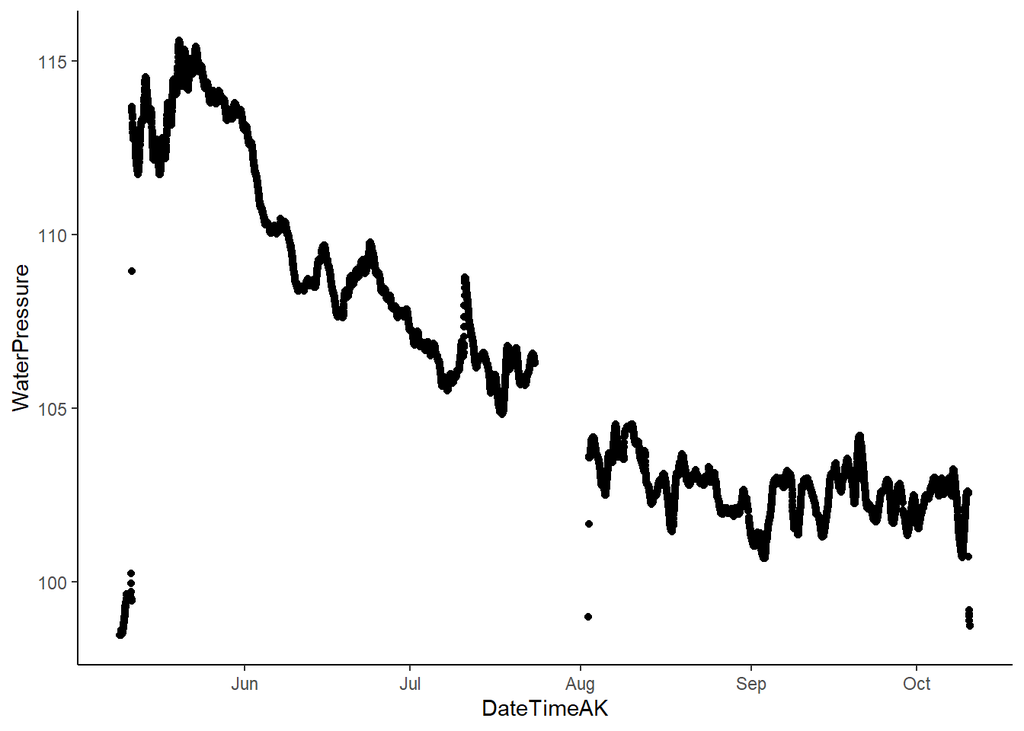

```r
ggplot(frch.stream.one.2022, aes(x = DateTimeAK, y = WaterPressure))+
  geom_point() +
  theme_classic()
```

This looks like the best one yet…we need to remove the out of water points

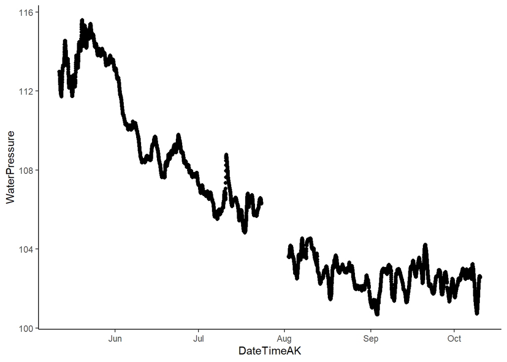

```r
frch.stream.one.2022 <- frch.stream.one.2022 %>%
  mutate(across(c(WaterPressure),
                ~ifelse(DateTimeAK >= "2022-05-09" & DateTimeAK <= "2022-05-12", NA, .))) # PT wasnt placed into the stream until 5/12

frch.stream.one.2022 <- frch.stream.one.2022 %>%
  mutate(across(c(WaterPressure),
                ~ifelse(DateTimeAK >= "2022-08-01" & DateTimeAK <= "2022-08-15" &
  WaterPressure < 102, NA, .))) %>% filter(WaterPressure > 98.4) # PT wasnt placed into the stream until 5/12

frch.stream.one.2022 <- frch.stream.one.2022 %>% filter(DateTimeAK < "2022-10-10 10:30:00")

ggplot(frch.stream.one.2022, aes(x = DateTimeAK, y = WaterPressure))+
  geom_point() +
  theme_classic()
```

This looks better

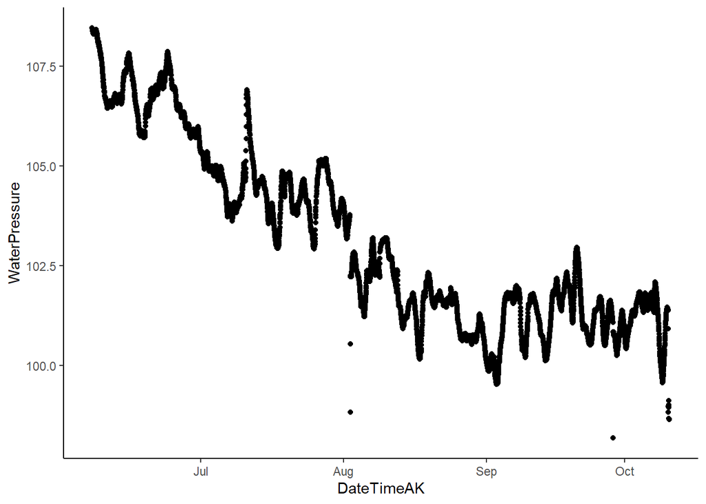

```r
ggplot(frch.stream.two.2022, aes(x = DateTimeAK, y = WaterPressure))+
  geom_point() +
  theme_classic()
```

PT2 also looks good…let me remove that one point in august that is below everything else

```r
frch.stream.two.2022 <- frch.stream.two.2022 %>%
  mutate(across(c(WaterPressure),
                ~ifelse(DateTimeAK >= "2022-08-01" & DateTimeAK <= "2022-08-15" &
  WaterPressure < 100, NA, .))) %>% filter(WaterPressure > 98.4)# PT wasnt placed into the stream until 5/12

# Shift step in August
frch2.before <- frch.stream.two.2022[c(1:2685), ]
frch2.after <- frch.stream.two.2022[c(2687:40000), ]
frch.stream.two.2022[2685, 2] - frch.stream.two.2022[2687, 2] # 1.5485
```

| WaterPressure |
| --- |
| 1.5485 |

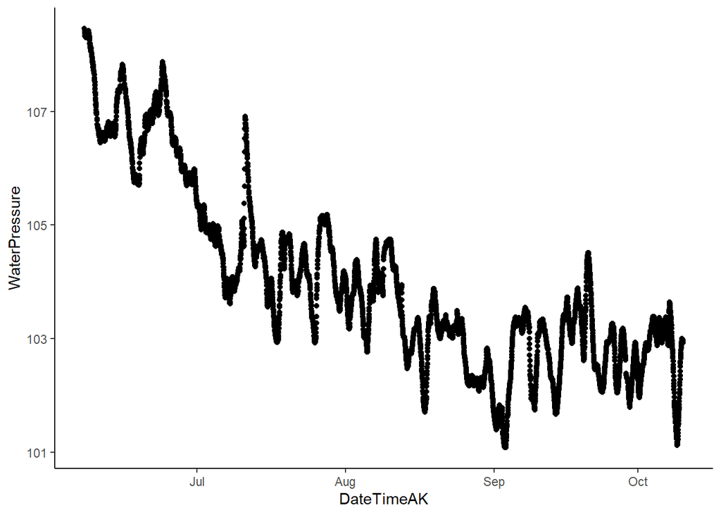

```r
frch2.after$WaterPressure <- frch2.after$WaterPressure + 1.5485
frch.stream.two.2022 <- rbind(frch2.before, frch2.after)

frch.stream.two.2022 <- frch.stream.two.2022 %>% filter(DateTimeAK < "2022-10-10 10:30:00")

frch.stream.two.2022 %>% #filter(DateTimeAK > "2022-10-05") %>%
  ggplot(aes(x = DateTimeAK, y = WaterPressure))+
  geom_point() +
  theme_classic()
```

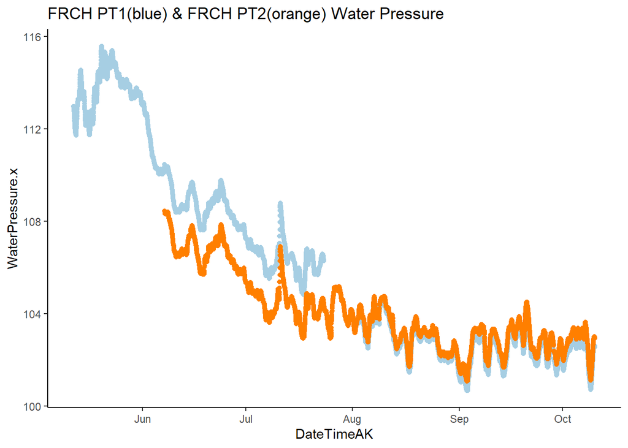

```r
# Checking closeness between two PTs
frch.pt.both <- full_join(frch.stream.one.2022, frch.stream.two.2022, by = "DateTimeAK")

ggplot(aes(x = DateTimeAK, y = WaterPressure.x), data = frch.pt.both) +
  geom_point(aes(x=DateTimeAK, y=WaterPressure.x), data = frch.pt.both, color="#A6CEE3") +
  geom_point(aes(x=DateTimeAK, y=WaterPressure.y), data = frch.pt.both, color="#FF7F00") +
  theme_classic() +
  ggtitle("FRCH PT1(blue) & FRCH PT2(orange) Water Pressure")
```

They look the same. Lets use PT1 except to fill the gap in July.

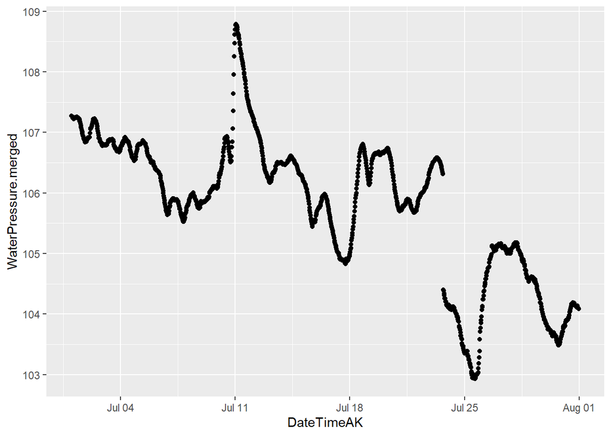

```r
frch.pt.both$WaterPressure.merged <- ifelse(frch.pt.both$DateTimeAK >= "2022-07-23 17:00:00" & frch.pt.both$DateTimeAK <= "2022-08-02 12:00:00", frch.pt.both$WaterPressure.y, frch.pt.both$WaterPressure.x)


frch.pt.both %>% filter(DateTimeAK > "2022-07-01" & DateTimeAK < "2022-08-01") %>%
  ggplot(aes(x = DateTimeAK, y = WaterPressure.merged)) +
  geom_point()
```

```r
## Clean merged water pressure data

# Shift step in July
frch.before <- frch.pt.both[c(1:3488), ]
frch.after <- frch.pt.both[c(3489:40000), ]
frch.pt.both[3488, 4] - frch.pt.both[3489, 4] # 1.914
```

| WaterPressure.merged |
| --- |
| 1.913667 |

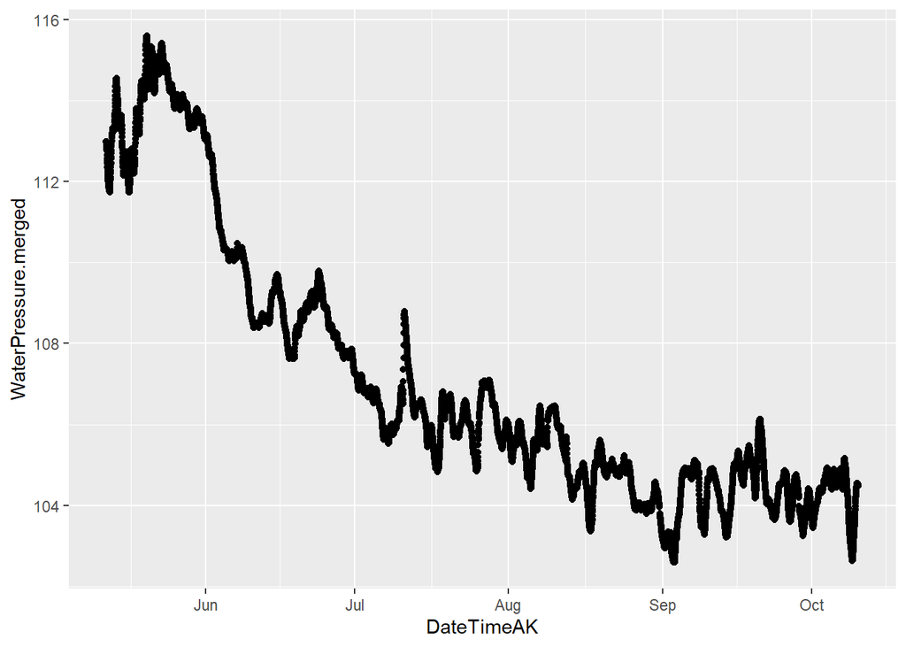

```r
frch.after$WaterPressure.merged <- frch.after$WaterPressure.merged + 1.914
frch.pt.both <- rbind(frch.before, frch.after)

frch.pt.both <- frch.pt.both %>% filter(!DateTimeAK %in% NA)

frch.pt.both %>% #filter(DateTimeAK > "2022-08-01" & DateTimeAK < "2022-08-05") %>%
  ggplot(aes(x = DateTimeAK, y = WaterPressure.merged)) +
  geom_point()
```

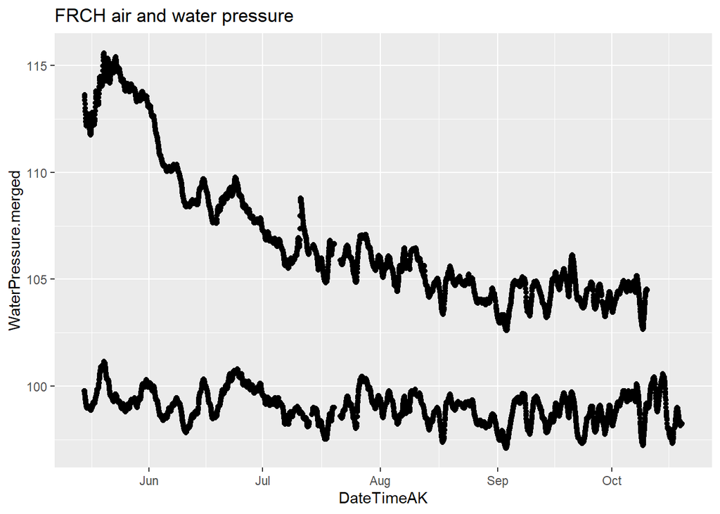

```r
# join the two atmospheric and water pressure together

frch.final.pressure.2022 <- frch.pt.both

FRCH.2022 <- left_join(eielson.atmo.2022.compare, frch.final.pressure.2022, by = "DateTimeAK")


# Water pressure - atmospheric pressure
FRCH.2022$difference <- FRCH.2022$WaterPressure.merged - FRCH.2022$AirPressureCorrectedFRCH

names(FRCH.2022)[names(FRCH.2022) == 'Site.x'] <- 'Site'

FRCH.2022$Site <- "FRCH"

FRCH.2022 %>% filter(DateTimeAK > "2022-05-15") %>%
  #filter(DateTimeAK > "2022-09-18" & DateTimeAK < "2022-09-22") %>%
  ggplot(aes(DateTimeAK, WaterPressure.merged)) + geom_point() + geom_point(aes(DateTimeAK, AirPressureCorrectedFRCH)) + #geom_vline (xintercept = as.POSIXct("2022-09-20 20:00:00"))
ggtitle("FRCH air and water pressure")
```

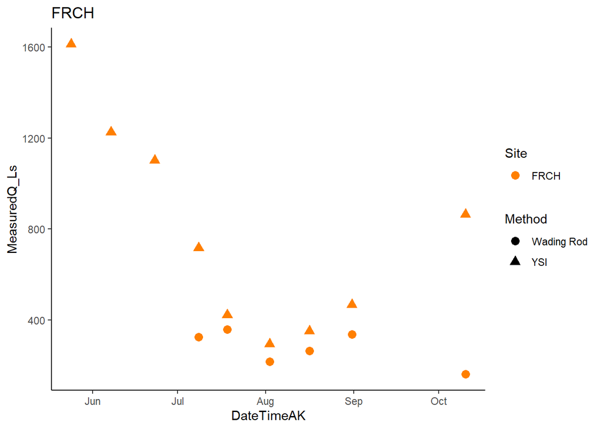

```r
### Filter FRCH ###
QSummary.FR.2022 <- QSummary.2022 %>% filter(Site =="FRCH")

ggplot(QSummary.FR.2022) +
  geom_point(aes(x = DateTimeAK, y = MeasuredQ_Ls, shape = Method, color = Site), size=3) +
  theme_classic() +
  scale_color_manual(values=c("#FF7F00")) +
  ggtitle("FRCH")
```

```r
# trying to merge by nearest date if we have an offset point
FRCH.2022.dt <- setDT(FRCH.2022)
QSummary.FR.2022.dt <- QSummary.FR.2022

French1comb.2022 <- FRCH.2022.dt[QSummary.FR.2022.dt, on = "DateTimeAK", roll = 'nearest']

FRCH1.lm.2022 <- lm(French1comb.2022$MeasuredQ_Ls ~ French1comb.2022$difference)
```

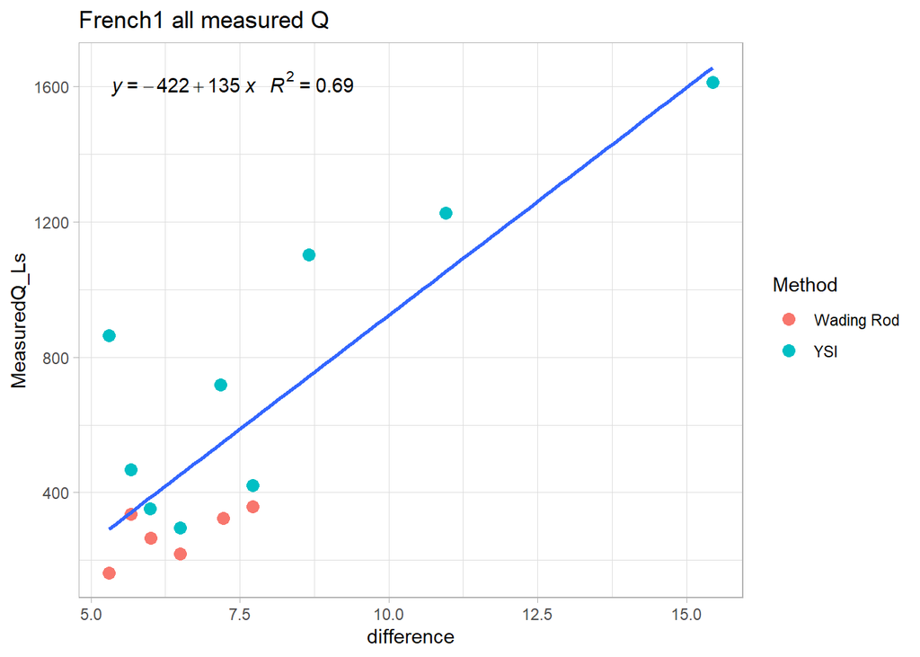

```r
# rating curve #
frch.formula <- y ~ x

ggplot(aes(x = difference, y = MeasuredQ_Ls), data = French1comb.2022) +
  geom_point(aes(color = Method), size = 3) +
  geom_smooth(method = "lm", se=FALSE, formula = frch.formula) +
  stat_poly_eq(formula = frch.formula,
               aes(label = paste(..eq.label.., ..rr.label.., sep = "~~~")),
               parse = TRUE) +
  theme_light() +
  ggtitle("French1 all measured Q")
```

Lets try seperate rating curves by method.

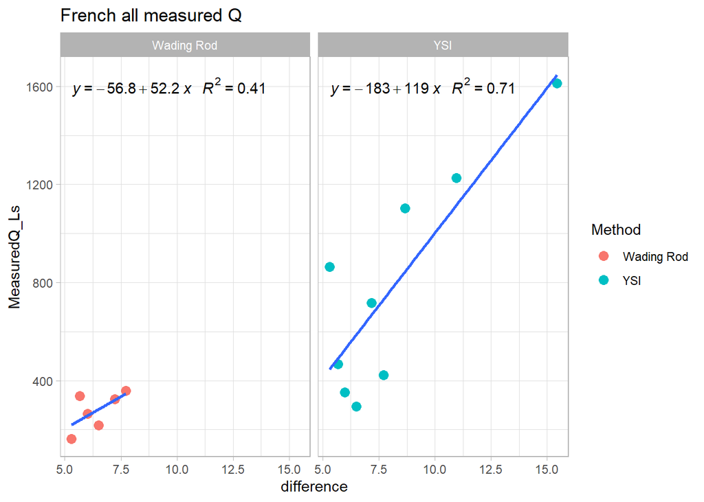

```r
# rating curve #
frch.formula <- y ~ x

ggplot(aes(x = difference, y = MeasuredQ_Ls), data = French1comb.2022) +
  geom_point(aes(color = Method), size = 3) +
  geom_smooth(method = "lm", se=FALSE, formula = frch.formula) +
  stat_poly_eq(formula = frch.formula,
               aes(label = paste(..eq.label.., ..rr.label.., sep = "~~~")),
               parse = TRUE) +
  #xlim(216, 216.4) +
  #ylim(0,1500) +
  theme_light() +
  ggtitle("French all measured Q") + facet_wrap(~Method)
```

Not good. How about a rating curve just with the wading rod measurements and the 3 low YSI points?

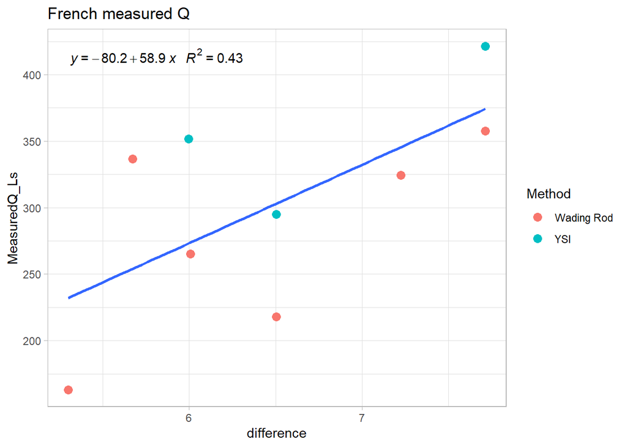

```r
French1comb.2022.2 <- French1comb.2022 %>% filter(MeasuredQ_Ls < 430)
# rating curve #
frch.formula <- y ~ x

ggplot(aes(x = difference, y = MeasuredQ_Ls), data = French1comb.2022.2) +
  geom_point(aes(color = Method), size = 3) +
  geom_smooth(method = "lm", se=FALSE, formula = frch.formula) +
  stat_poly_eq(formula = frch.formula,
               aes(label = paste(..eq.label.., ..rr.label.., sep = "~~~")),
               parse = TRUE) +
  #xlim(216, 216.4) +
  #ylim(0,1500) +
  theme_light() +
  ggtitle("French measured Q")
```

Not good at low Q, but lets add back in the two high difference YSI points.

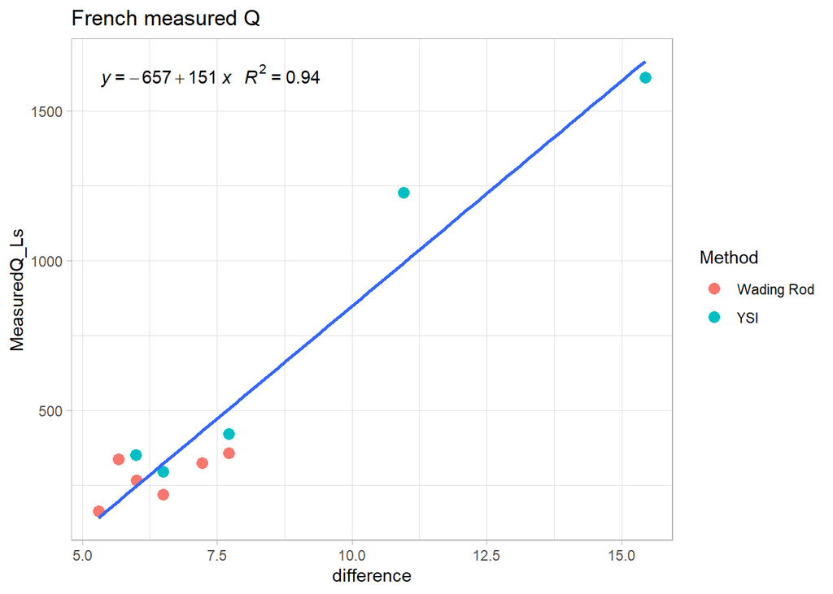

```r
French1comb.2022.3 <- French1comb.2022 %>% filter(MeasuredQ_Ls < 430 | difference > 10)
# rating curve #
frch.formula <- y ~ x

ggplot(aes(x = difference, y = MeasuredQ_Ls), data = French1comb.2022.3) +
  geom_point(aes(color = Method), size = 3) +
  geom_smooth(method = "lm", se=FALSE, formula = frch.formula) +
  stat_poly_eq(formula = frch.formula,
               aes(label = paste(..eq.label.., ..rr.label.., sep = "~~~")),
               parse = TRUE) +
  #xlim(216, 216.4) +
  #ylim(0,1500) +
  theme_light() +
  ggtitle("French measured Q")
```

```r
## Predict STRT Q
FRCH.lm.2022 <- lm(French1comb.2022.3$MeasuredQ_Ls ~ French1comb.2022.3$difference)
summary(FRCH.lm.2022)
```

```
##
## Call:
## lm(formula = French1comb.2022.3$MeasuredQ_Ls ~ French1comb.2022.3$difference)
##
## Residuals:
##     Min      1Q  Median      3Q     Max
## -146.45  -93.31  -27.19   64.25  233.73
##
## Coefficients:
##                               Estimate Std. Error t value Pr(>|t|)
## (Intercept)                    -656.90     108.93   -6.03 0.000195 ***
## French1comb.2022.3$difference   150.50      13.22   11.38 1.21e-06 ***
## ---
## Signif. codes:  0 '***' 0.001 '**' 0.01 '*' 0.05 '.' 0.1 ' ' 1
##
## Residual standard error: 124.9 on 9 degrees of freedom
## Multiple R-squared:  0.935,  Adjusted R-squared:  0.9278
## F-statistic: 129.5 on 1 and 9 DF,  p-value: 1.207e-06
```

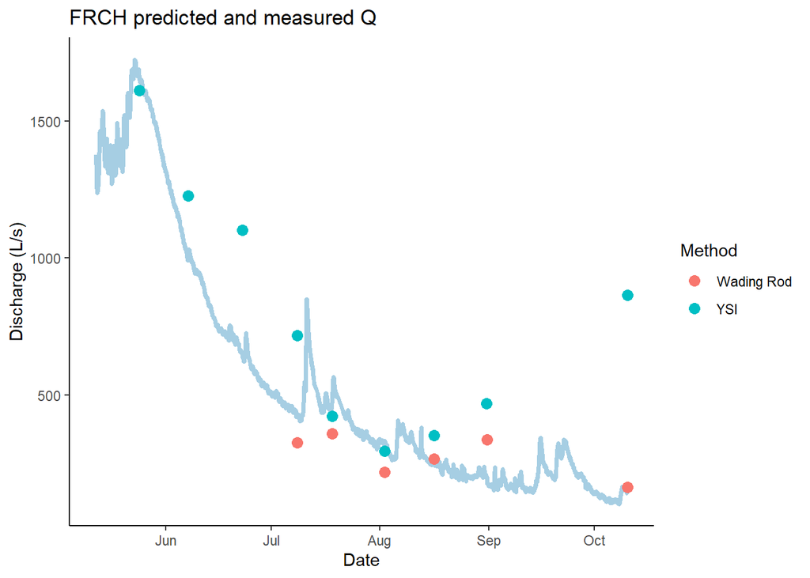

```r
FRCH.2022.dt$pred.frch.Q <- coef(FRCH.lm.2022)[2] * FRCH.2022.dt$difference + coef(FRCH.lm.2022)[1]

FRCH.2022.dt <- FRCH.2022.dt %>% filter(!pred.frch.Q %in% NA)

FRCH.2022.dt %>% ggplot(aes(x = DateTimeAK, y = pred.frch.Q)) +
  geom_line(color="#A6CEE3", size=1.25) +
  geom_point(data = French1comb.2022, aes(x = DateTimeAK, y = MeasuredQ_Ls, color = Method), size=3) +
  theme_classic() +
  ggtitle("FRCH predicted and measured Q") +
  xlab("Date") +
  ylab("Discharge (L/s)")
```

This doesn’t fit well at low Q especially.

### VAUL

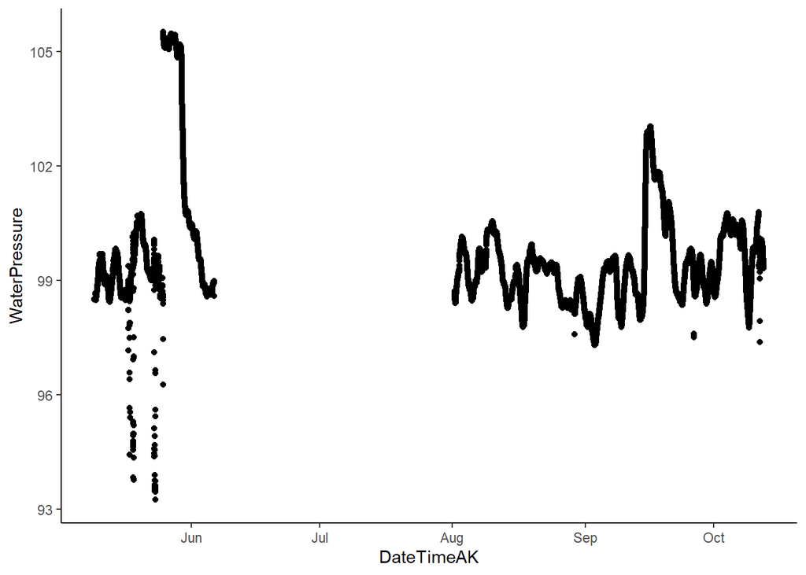

```r
vaul.stream.one.2022.url <- "https://docs.google.com/spreadsheets/d/e/2PACX-1vQf78OhtBtjvs6HmnEVPJ0PVYSlpIjVAom5VIv12LhZDMbezaFb-LJCGMZUoyVjLJI-pqizM-Be2hbl/pubhtml"
vaul.stream.two.2022.url <- "https://docs.google.com/spreadsheets/d/e/2PACX-1vSR7qqdF5BXklT1ocG9bLLUwJ07ha8qmzAVRPaUjm7mUq12VptmViI9NJcW1-jO4cu0KtHBLl90A4DZ/pub?output=csv"

# load in url
vaul.stream.one.2022 <- read.csv(url(vaul.stream.one.2022.url), skip = 1)
vaul.stream.two.2022 <- read.csv(url(vaul.stream.two.2022.url), skip = 1)

# clean for merging purposes
vaul.stream.one.2022 <- vaul.stream.one.2022[, -c(5:13)] # removing columns that arent date/abs pressure and temp

vaul.stream.two.2022 <- vaul.stream.two.2022[, -c(5:13)] # removing columns that arent date/abs pressure and temp

# changing to AK time (It reads in as GMT but it is actually AKST )

vaul.stream.two.2022$DateTimeAK <- mdy_hms(vaul.stream.two.2022$Date.Time..GMT.08.00)

vaul.stream.two.2022$DateTimeAK <- force_tz(vaul.stream.two.2022$DateTimeAK, "America/Anchorage")

#vaul.stream.one.2022$DateTimeAK <- mdy_hms(vaul.stream.one.2022$Date.Time..GMT.08.00)

#vaul.stream.one.2022$DateTimeAK <- force_tz(vaul.stream.one.2022$DateTimeAK, "America/Anchorage")


# round date to 5 minute intervals
#vaul.stream.one.2022$DateTimeAK <- lubridate::round_date(vaul.stream.one.2022$DateTimeAK, "5 minutes")
vaul.stream.two.2022$DateTimeAK <- lubridate::round_date(vaul.stream.two.2022$DateTimeAK, "5 minutes")

# cleaning off original datetime
#vaul.stream.one.2022 <- vaul.stream.one.2022[, -c(2)] # removing columns that aren't date/abs pressure and temp
vaul.stream.two.2022 <- vaul.stream.two.2022[, -c(2)] # removing columns that arent

#names(vaul.stream.one.2022) <- c("Site", "WaterPressure", "TempC", "DateTimeAK")

names(vaul.stream.two.2022) <- c("Site", "WaterPressure", "TempC", "DateTimeAK")

ggplot(vaul.stream.two.2022, aes(x = DateTimeAK, y = WaterPressure))+
  geom_point() +
  theme_classic()
```

This is the raw record of VAUL pressure. The beginning is airpressure and then there is a gap as we had a relaunch issue.

```r
vaul.stream.two.2022 <- vaul.stream.two.2022 %>%
  mutate(across(c(WaterPressure),
                ~ifelse(DateTimeAK <= "2022-05-26", NA, .))) # PT wasnt placed into the stream until 5/26

vaul.stream.two.2022 <- vaul.stream.two.2022 %>%
  mutate(across(c(WaterPressure),
                ~ifelse(DateTimeAK >= "2022-08-15" & DateTimeAK <= "2022-08-31" &
  WaterPressure < 98, NA, .)))

vaul.stream.two.2022 <- vaul.stream.two.2022 %>%
  mutate(across(c(WaterPressure),
                ~ifelse(DateTimeAK >= "2022-09-20" & DateTimeAK <= "2022-10-01" &
  WaterPressure < 98, NA, .)))

vaul.stream.two.2022 <- vaul.stream.two.2022 %>%
  mutate(across(c(WaterPressure),
                ~ifelse(DateTimeAK >= "2022-10-10" &
  WaterPressure < 99, NA, .)))

# Clear up strange messiness on 10/11
vaul.stream.two.2022 <- vaul.stream.two.2022 %>%
  mutate(across(c(WaterPressure),
                ~ifelse(DateTimeAK > "2022-10-11 13:55:00" & DateTimeAK < "2022-10-11 19:10:00", NA, .)))
a <- vaul.stream.two.2022 %>% filter(DateTimeAK == "2022-10-11 13:55:00")
b<- vaul.stream.two.2022 %>% filter(DateTimeAK == "2022-10-11 19:10:00")
a$WaterPressure-b$WaterPressure # 0.924
```

```
## [1] 0.924
```

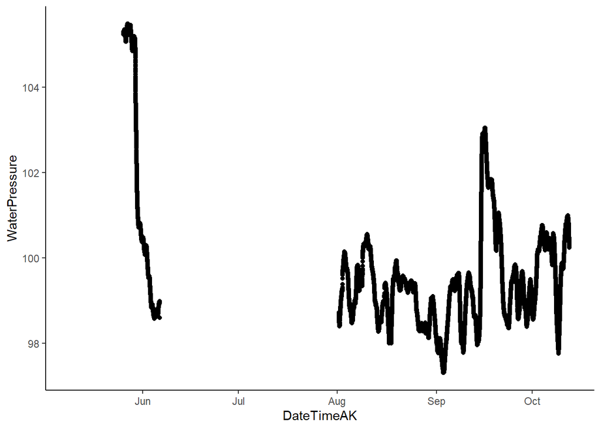

```r
vaul.stream.two.2022 <- vaul.stream.two.2022 %>%
  mutate(across(c(WaterPressure),
                ~ifelse(DateTimeAK < "2022-10-11 19:10:00", WaterPressure, WaterPressure + 0.924)))

vaul.stream.two.2022 %>%
  #filter(DateTimeAK > "2022-10-10") %>%
  ggplot( aes(x = DateTimeAK, y = WaterPressure))+
  geom_point() +
  theme_classic()
```

That is better. Crazy how fast the water level comes down at VAUL

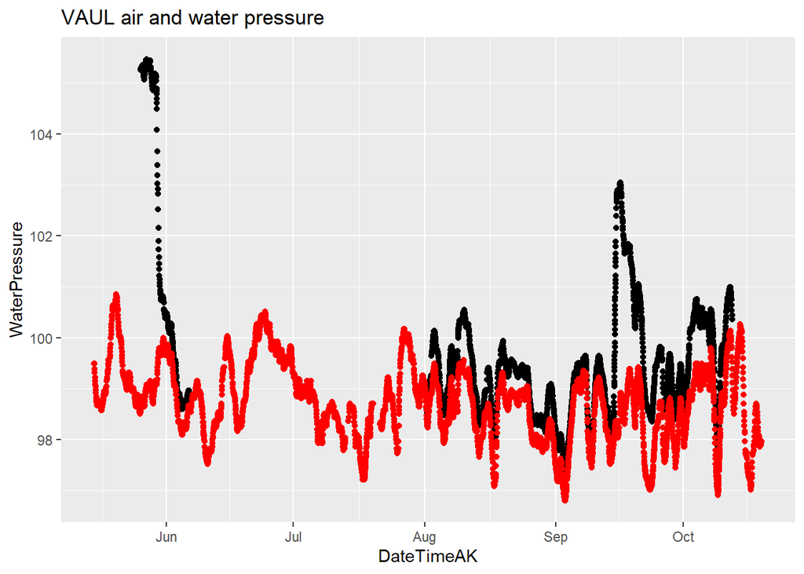

```r
# Join the atmospheric and water pressure together
vaul.final.pressure.2022 <- vaul.stream.two.2022
# Eielson atmosphere data
VAUL.2022 <- left_join(eielson.atmo.2022.compare, vaul.final.pressure.2022 , by = "DateTimeAK")

# Water pressure - atmospheric pressure
VAUL.2022$difference <- VAUL.2022$WaterPressure - VAUL.2022$AirPressureCorrectedVAUL

VAUL.2022 <-  VAUL.2022[ , -which(names(VAUL.2022) %in% c("TempC"))] # removing columns I do not need

VAUL.2022$Site <- "VAUL"

# Plot air and water pressure
VAUL.2022 %>% filter(DateTimeAK > "2022-05-15") %>%
  ggplot(aes(DateTimeAK, WaterPressure)) + geom_point() + geom_point(aes(DateTimeAK, AirPressureCorrectedVAUL), color = "red") +
  ggtitle("VAUL air and water pressure")
```

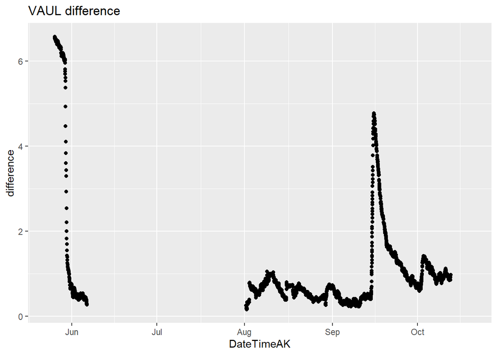

```r
vaul.final.pressure.2022.2 <- vaul.final.pressure.2022

VAUL.2022.2 <- left_join(eielson.atmo.2022.compare, vaul.final.pressure.2022.2, by = "DateTimeAK") %>% filter(DateTimeAK > "2022-05-24")

# Water pressure - atmospheric pressure
VAUL.2022.2$difference <- VAUL.2022.2$WaterPressure - VAUL.2022.2$AirPressureCorrectedVAUL


# Plot difference
VAUL.2022.2 %>% ggplot(aes(DateTimeAK, difference)) + geom_point() + ggtitle("VAUL difference")
```

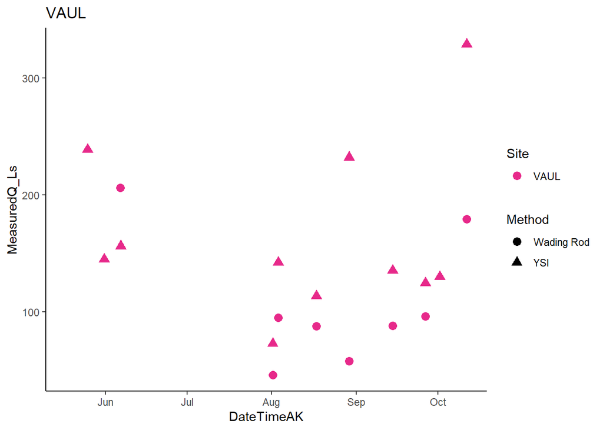

```r
### Filter VAUL ###
# Remove measurements during pressure gap!
QSummary.VA.2022 <- QSummary.2022 %>% filter(Site =="VAUL") %>% filter(DateTimeAK < "2022-06-07" | DateTimeAK > "2022-08-01")

ggplot(QSummary.VA.2022) +
  geom_point(aes(x = DateTimeAK, y = MeasuredQ_Ls, shape = Method, color = Site), size=3) +
  theme_classic() +
  scale_color_manual(values=c("#E7298A")) +
  ggtitle("VAUL")
```

```r
# Merge by nearest date if we have an offset point
VAUL.2022.dt <- setDT(VAUL.2022.2) %>% filter(!WaterPressure %in% NA)
QSummary.VA.2022.dt <- QSummary.VA.2022 %>% filter(DateTimeAK > "2022-05-25" & DateTimeAK < "2022-10-01")

Vault1comb.2022 <- VAUL.2022.dt[QSummary.VA.2022.dt, on = "DateTimeAK", roll = 'nearest']
```

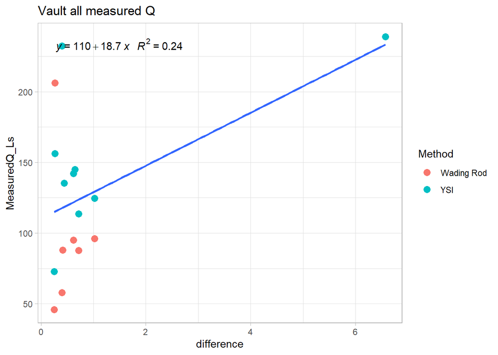

```r
# rating curve #
vaul.formula <- y ~ x

Vault1comb.2022  %>% ggplot(aes(x = difference, y = MeasuredQ_Ls)) +
  geom_point(aes(color = Method), size = 3) +
  geom_smooth(method = "lm", se=FALSE, formula = vaul.formula) +
  stat_poly_eq(formula = vaul.formula,
               aes(label = paste(..eq.label.., ..rr.label.., sep = "~~~")),
               parse = TRUE) +
  theme_light() +
  ggtitle("Vault all measured Q")
```

That very high difference could be accurate, but necessary to remove for curve. Let’s also remove the two low difference, high Q points.

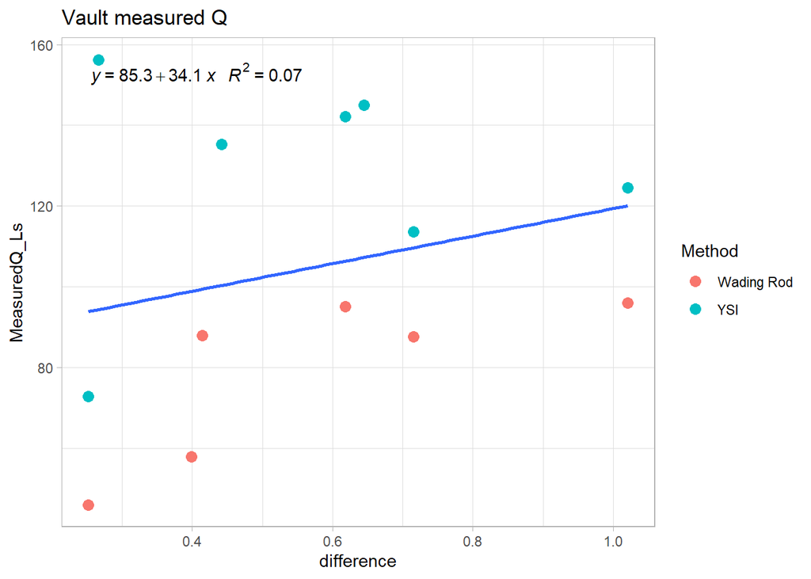

```r
# Remove high difference point
Vault1comb.2022.2 <- Vault1comb.2022 %>% filter(MeasuredQ_Ls < 200)

# rating curve #
vaul.formula <- y ~ x

Vault1comb.2022.2  %>% ggplot(aes(x = difference, y = MeasuredQ_Ls)) +
  geom_point(aes(color = Method), size = 3) +
  geom_smooth(method = "lm", se=FALSE, formula = vaul.formula) +
  stat_poly_eq(formula = vaul.formula,
               aes(label = paste(..eq.label.., ..rr.label.., sep = "~~~")),
               parse = TRUE) +
  theme_light() +
  ggtitle("Vault measured Q")
```

Let’s try curve with wading rod and YSI averaged by date.

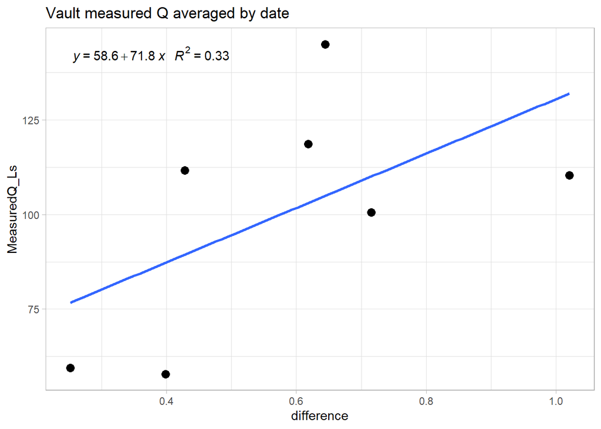

```r
Vault1comb.2022.3 <- Vault1comb.2022.2 %>% group_by(Date) %>% summarise(MeasuredQ_Ls = mean(MeasuredQ_Ls),
difference = mean(difference))

# rating curve #
vaul.formula <- y ~ x

Vault1comb.2022.3 %>% filter(MeasuredQ_Ls < 150) %>% ggplot(aes(x = difference, y = MeasuredQ_Ls)) +
  geom_point(size = 3) +
  geom_smooth(method = "lm", se=FALSE, formula = vaul.formula) +
  stat_poly_eq(formula = vaul.formula,
               aes(label = paste(..eq.label.., ..rr.label.., sep = "~~~")),
               parse = TRUE) +
  theme_light() +
  ggtitle("Vault measured Q averaged by date")
```

Let’s try separate curves for YSI and wading rod

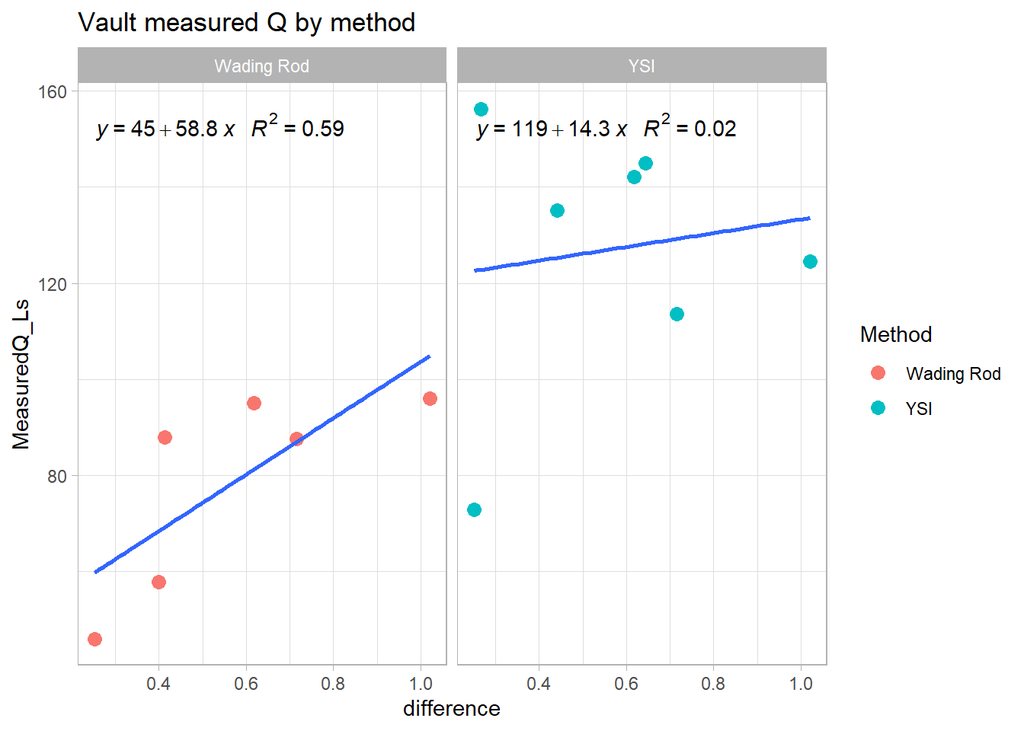

```r
# rating curve #
vaul.formula <- y ~ x

Vault1comb.2022.2  %>% ggplot(aes(x = difference, y = MeasuredQ_Ls)) +
  geom_point(aes(color = Method), size = 3) +
  geom_smooth(method = "lm", se=FALSE, formula = vaul.formula) +
  stat_poly_eq(formula = vaul.formula,
               aes(label = paste(..eq.label.., ..rr.label.., sep = "~~~")),
               parse = TRUE) +
  #xlim(216, 216.4) +
  #ylim(0,1500) +
  theme_light() +
  ggtitle("Vault measured Q by method") + facet_wrap(~Method)
```

Maybe the best we can do is using the wading rod points with a couple low YSI points.

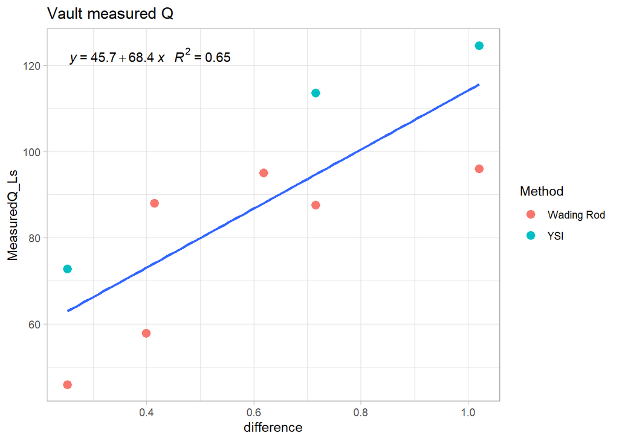

```r
# Remove high difference point
Vault1comb.2022.3 <- Vault1comb.2022 %>% filter(MeasuredQ_Ls < 130)

# rating curve #
vaul.formula <- y ~ x

Vault1comb.2022.3  %>% ggplot(aes(x = difference, y = MeasuredQ_Ls)) +
  geom_point(aes(color = Method), size = 3) +
  geom_smooth(method = "lm", se=FALSE, formula = vaul.formula) +
  stat_poly_eq(formula = vaul.formula,
               aes(label = paste(..eq.label.., ..rr.label.., sep = "~~~")),
               parse = TRUE) +
  theme_light() +
  ggtitle("Vault measured Q")
```

```r
## Predict VAUL Q
VAUL.lm.2022 <- lm(Vault1comb.2022.3$MeasuredQ_Ls ~ Vault1comb.2022.3$difference)
summary(VAUL.lm.2022)
```

```
##
## Call:
## lm(formula = Vault1comb.2022.3$MeasuredQ_Ls ~ Vault1comb.2022.3$difference)
##
## Residuals:
##     Min      1Q  Median      3Q     Max
## -19.553 -15.136   7.053   9.842  18.884
##
## Coefficients:
##                              Estimate Std. Error t value Pr(>|t|)
## (Intercept)                     45.75      12.45   3.675  0.00791 **
## Vault1comb.2022.3$difference    68.40      18.80   3.639  0.00830 **
## ---
## Signif. codes:  0 '***' 0.001 '**' 0.01 '*' 0.05 '.' 0.1 ' ' 1
##
## Residual standard error: 15.71 on 7 degrees of freedom
## Multiple R-squared:  0.6541, Adjusted R-squared:  0.6047
## F-statistic: 13.24 on 1 and 7 DF,  p-value: 0.008303
```

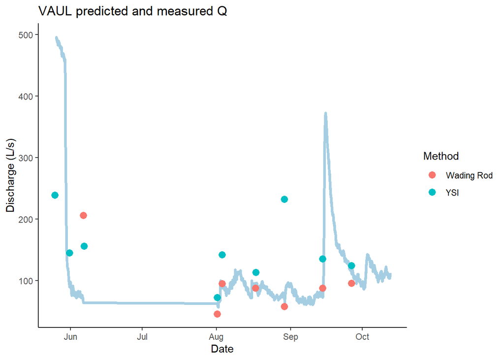

```r
VAUL.2022.dt$pred.vaul.Q <- coef(VAUL.lm.2022)[2] * VAUL.2022.dt$difference + coef(VAUL.lm.2022)[1]

VAUL.2022.dt <- VAUL.2022.dt %>% select(DateTimeAK, pred.vaul.Q) %>% na.omit()

VAUL.2022.dt %>% ggplot(aes(x = DateTimeAK, y = pred.vaul.Q)) +
  geom_line(color="#A6CEE3", size=1.25) +
  geom_point(data = Vault1comb.2022, aes(x = DateTimeAK, y = MeasuredQ_Ls, color = Method), size=3) +
  theme_classic() +
  ggtitle("VAUL predicted and measured Q") +
  xlab("Date") +
  ylab("Discharge (L/s)")
```